# Declining demographic performance and dispersal limitation influence the geographic distribution of the perennial forb Astragalus utahensis (Fabaceae) - Baer - 2019 - Journal of Ecology - Wiley Online

[Journal of Ecology](https://besjournals.onlinelibrary.wiley.com/journal/13652745)

[Volume 107, Issue 3](https://besjournals.onlinelibrary.wiley.com/toc/13652745/2019/107/3) p. 1250-1262

[figure not shown]

RESEARCH ARTICLE

Free Access

# Declining demographic performance and dispersal limitation influence the geographic distribution of the perennial forb *Astragalus utahensis* (Fabaceae)

[Kathryn C. Baer](https://besjournals.onlinelibrary.wiley.com/action/doSearch?ContribAuthorRaw=Baer%2C+Kathryn+C),

[John L. Maron](https://besjournals.onlinelibrary.wiley.com/action/doSearch?ContribAuthorRaw=Maron%2C+John+L),

First published: 16 October 2018

https://doi.org/10.1111/1365-2745.13086

Citations: 6

## Abstract

1. A central goal of ecology is understanding the determinants of species’ distributions. “Metapopulation” models for the existence of distributional boundaries predict that species’ geographic ranges arise from the landscape-scale deterioration of habitat suitability towards the range edge (i.e., niche mechanisms), which simultaneously hinders demographic performance and limits dispersal to suitable habitat beyond the edge (i.e., dispersal limitation). However, few studies have examined both of these mechanisms for the same species by examining abundance and comprehensive measures of demographic performance across the distribution and beyond its boundary.
2. We tested the predictions of metapopulation models for range limits by contrasting abundance, demographic performance, and population growth (*λ*) of the perennial forb *Astragalus utahensis* in central and northern range edge populations. We tested for dispersal limitation by transplanting individuals at and beyond the northern range boundary and monitoring their demographic performance.
3. *Astragalus* abundance and stochastic *λ* decreased from the range centre to the northern range edge, with stochastic *λ* falling to or below replacement in range edge populations. However, transplants at some sites beyond the northern range edge survived and reproduced at levels similar to transplants within the range. Thus, in addition to deteriorating conditions at the range edge, dispersal limitation appears to contribute to limiting *A. utahensis’* northern distribution*.*
4. *Synthesis.* Our results support metapopulation models for range limits by suggesting that decreased demographic performance constrains the viability of range edge populations while contributing to dispersal limitation of *Astragalus utahensis’* distribution. Thus, the tandem action of niche and dispersal processes appears to play an important role in constraining this species’ northern latitudinal range.

## 1 INTRODUCTION

The relative importance of niche vs. dispersal limitation as proximate drivers of species’ range limits remains a topic of substantial debate in ecology (e.g., Angert, Bayly, Sheth, & Paul, 2018; Hargreaves, Samis, & Eckert, 2014; Lee-Yaw et al., 2016). While evolutionary constraints play an important role in determining a species’ ability to adapt to new environmental conditions, in a proximate sense stable range limits are often thought to be imposed by either declining environmental suitability at or beyond the range edge (i.e., niche processes) or a limited ability to disperse to suitable habitat beyond the range boundary (dispersal limitation; Sexton, McIntyre, Angert, & Rice, 2009). However, current theory suggests that both niche and dispersal limitation may interact to determine range boundaries. (Carter & Prince, 1981; 1988; Gaston, 2009; Holt & Keitt, 2000; Holt, Keitt, Lewis, Maurer, & Taper, 2005). Yet, studies that simultaneously test for the importance of both of these mechanisms in setting range limits remain scarce. Increased understanding of how these mechanisms simultaneously determine range boundaries is essential for furthering many facets of macroecological and biogeographical theory.

Niche-based explanations for stable distributional limits posit that a decline in environmental suitability at or beyond the edge of a species’ distribution leads to an inability to maintain viable populations beyond the edge (Holt, 2003; Lee-Yaw et al., 2016). Perhaps the most well-known niche-based theory stems from the predictions of the abundant centre hypothesis (hereafter ACH; Brown, 1984; Hengeveld & Haeck, 1982; reviewed in Pironon et al., 2017; Sagarin & Gaines, 2002; Sagarin, Gaines, & Gaylord, 2006; Sexton et al., 2009). According to the ACH and related hypotheses, a spatially autocorrelated decrease in environmental suitability from the centre to the periphery of the distribution causes a monotonic decline in the abundance of a species due to declining density-independent demographic performance. While intuitively appealing, support for these predictions is equivocal (Abeli, Gentili, Mondoni, Orsenigo, & Rossi, 2014; Dallas, Decker, & Hastings, 2017; Pironon et al., 2017; Sagarin & Gaines, 2002; Sexton et al., 2009). However, although declining abundance and performance from the centre to the edge of the distribution may not be a biogeographical “rule of thumb” (Sagarin & Gaines, 2002), this does not indicate that niche processes play no role in limiting the ranges of species. A species’ distribution may be limited by niche processes even under more realistic scenarios in which its performance declines abruptly at the range limit or changes in a non-monotonic way across the landscape, so long as the species is still incapable of maintaining viable populations beyond the range edge (Sagarin et al., 2006; Sexton et al., 2009).

An alternative to niche-based explanations for stable range limits is dispersal limitation. When a species’ range is dispersal limited, suitable habitat exists beyond the range edge but the species cannot disperse into this habitat (Hargreaves et al., 2014; Lee-Yaw et al., 2016). This contrasts with niche-based hypotheses, which predict that no suitable habitat should exist beyond the range edge. Transplant studies comparing vital rates within and beyond the range are required for gauging the availability of suitable niche space beyond the distributional edge (Gaston, 2009; Hargreaves et al., 2014). In roughly one quarter of these studies, demographic performance is similar or greater beyond latitudinal or longitudinal range edges compared to within the range, suggesting dispersal limitation of these distributions is somewhat common (Hargreaves et al., 2014; e.g., Norton, Firbank, Scott, & Watkinson, 2005; Prince & Carter, 1985; Samis & Eckert, 2009). In contrast, demographic performance nearly always declines beyond elevational range limits, suggesting that these edges are in most cases limited by niche processes rather than dispersal limitation (Hargreaves et al., 2014; e.g., Angert & Schemske, 2005; Bruelheide & Scheidel, 1999; Klimeš & Doležal, 2010). Climatic conditions change more abruptly across elevational than latitudinal space, which may explain the general lack of suitable niche space beyond elevational range boundaries, in contrast to patterns observed beyond latitudinal and longitudinal range edges (Phillips, 2012).

While niche- and dispersal-based explanations for stable range limits are generally presented as mutually exclusive alternatives, both processes likely act in concert to determine the latitudinal or longitudinal range limits of many species. “Metapopulation” models acknowledge this interaction by proposing that declining landscape-scale performance and higher probability of local extinction at the edge of the distribution (driven by niche processes) limits the ability of species to colonize suitable habitat over the range edge (i.e., dispersal limitation; Carter & Prince, 1981; 1988; Gaston, 2009; Holt & Keitt, 2000; Holt et al., 2005). In the context of these models, landscape-scale performance refers to the performance or abundance of a species averaged across a large geographic area (Gaston, 2009). Declining performance within individual populations is not required for the establishment of range limits under the predictions of all metapopulation models, since some models simply predict fewer and less connected populations at the range edge due to a decline in the availability of suitable habitat. Nonetheless, decreased performance within individual populations at the range edge may exacerbate dispersal limitation by further limiting the viability of, and propagule production in, edge populations (Gaston, 2009; Holt & Keitt, 2000; Holt et al., 2005; Münzbergová & Herben, 2005). Thus, while metapopulation models and niche-based explanations for range limits, such as the ACH, may produce similar predictions for patterns of environmentally determined species performance towards or at the edge of the distribution as compared to the centre, they fundamentally disagree in their predictions regarding the presence of suitable habitat beyond the range edge. Niche-based hypotheses predict that no suitable habitat exists beyond the range edge, and metapopulation models predict that suitable habitat exists beyond the range edge but remains unoccupied due to decreased connectivity of and/or dispersal among populations towards the edge (Carter & Prince, 1981; 1988; Gaston, 2009; Holt & Keitt, 2000; Holt et al., 2005). Testing the predictions of metapopulation models for range limits requires quantifying the tandem role of dispersal limitation and declining performance with proximity to the range edge and beyond the range, an approach that is rarely taken (Angert et al., 2018; Hargreaves et al., 2014).

One limitation of many past range limit studies is that they have examined only one or a few demographic parameters as proxies for population-scale performance. This approach can yield misleading conclusions because single vital rates may not be reflective of population-scale performance (Gaston, 2009; Sexton et al., 2009). For example, Doak and Morris (2010) found that despite lower survival and recruitment at the southern edge than the centre of *Silene acaulis’* latitudinal distribution, population growth rate was higher in this area due to compensatory higher rates for growth and aspects of reproduction. Such demographic compensation may be common (Villellas, Doak, García, & Morris, 2015).

A more robust approach for understanding range limits involves using measurements of all vital rates to project population growth rate (*λ*) in populations across a range. Studies of this kind remain relatively uncommon and have yielded contrasting conclusions. In plants, some studies have supported the ACH-proposed pattern of declining *λ* towards the range boundary (Pironon et al., 2017; e.g., Eckhart et al., 2011; Stanton-Geddes, Tiffin, & Shaw, 2012), while others have found no difference or higher *λ* at the periphery than the centre (Pironon et al., 2017; e.g., Doak & Morris, 2010; García, Goñi, & Guzmán, 2010; Pironon, Villellas, Morris, Doak, & García, 2015; Samis & Eckert, 2009; Stokes, Bullock, & Watkinson, 2004). Research that has compared *λ* or lifetime fitness at and beyond the latitudinal or longitudinal range edge is nearly non-existent (but see Samis & Eckert, 2009; Stanton-Geddes et al., 2012). Examinations of multiple demographic rates of transplants at and beyond the range edge are informative, but have yielded mixed evidence for the ability of species to maintain viable populations outside the range (Hargreaves et al., 2014; e.g., Geber & Eckhart, 2005; Levin & Clay, 1984; Norton et al., 2005).

We are aware of only two studies that have addressed metapopulation model predictions by simultaneously testing for declining *λ* across the latitudinal distribution as predicted by ACH-derived niche-based hypotheses and the ability to maintain viable populations beyond the distribution as predicted by dispersal-based hypotheses (Samis & Eckert, 2009; Stanton-Geddes et al., 2012). These studies found evidence for either niche limitation (Stanton-Geddes et al., 2012) or dispersal limitation (Samis & Eckert, 2009), but not both. Further research is needed that evaluates integrative measures of species performance across and beyond the distribution in order to test the predictions of metapopulation models for the determinants of range limits.

In this study, we evaluated predictions of metapopulation models (Carter & Prince, 1981; 1988; Gaston, 2009; Holt & Keitt, 2000; Holt et al., 2005) for the existence of the northern range limit of the perennial forb *Astragalus utahensis*. To do this, we simultaneously assessed over multiple years how *A. utahensis* abundance, demographic performance, and population growth varied from its range centre to northern range edge, and coupled these measurements with assessments of demographic performance in transplant sites at and beyond the range boundary. We sought to test two specific predictions of metapopulation models for the mechanisms underlying range limits (Carter & Prince, 1981; 1988; Gaston, 2009; Holt & Keitt, 2000; Holt et al., 2005): (a) local abundance, demographic performance, and stochastic population growth of *A. utahensis* should decrease from the range centre to the range boundary, and (b) individual *A. utahensis* plants should be able to establish self-sustaining populations beyond the northern range boundary.

## 2 MATERIALS AND METHODS

### 2.1 Study system

*Astragalus utahensis* (Fabaceae) is a perennial forb whose north–south geographic distribution extends from southeastern Idaho, USA (roughly 43°N), to southern Utah, USA (roughly 38°N). *Astragalus utahensis* is ideal for testing hypotheses regarding the proximate determinants of geographic range boundaries because it has a small but abiotically heterogeneous geographic distribution, distinct population boundaries, and a seed-based, non-clonal reproductive system. *Astragalus utahensis* occurs in isolated populations located on sparsely vegetated hillsides throughout its distribution. Plants flower from late April to early June, producing racemes composed of 3–10 showy magenta flowers. Relatively heavy seed pods fall under plants, dispersing seeds an average of <1 m from the maternal plant (Green, 1976).

We defined the centre of the distribution as the latitudinal midpoint between the northernmost and southernmost recorded populations and chose three “central” populations near this location for inclusion in this study (Figure 1). We also included four populations at the northern range edge. Although populations were labelled as “central” or “northern,” one “central” population (Providence) was further north than the others with the same designation and one “northern edge” population (Nordic Centre) was further south than the other northern edge populations. Both central and northern edge study populations were identified either from herbarium records or during an extensive search along road corridors near previously recorded populations (Figure 1). The study populations were chosen because they were the closest to either the centre or the northern edge of the latitudinal distribution and contained sufficient numbers of *A. utahensis* to allow for the collection of demographic data necessary to construct population projection models. While a small number of less dense, more isolated populations were identified in both the north and the centre of the distribution, the chosen sites were assumed to adequately represent the majority of populations and the most common conditions in their respective portions of the range based upon our observations of populations at each location in the range. The herbarium records used to identify some of the northern edge populations date from 1971, indicating a northern range limit that has remained stable for over 40 years. Searches along road corridors north of the furthest north study population yielded no evidence of populations in these areas; as such, we do not find evidence of a northward range shift in response to recent climate change. Ideally, density and demographic rates would be examined at both the northern and southern edges of the latitudinal distribution, but this approach was not logistically feasible for this study. Since climate niche modelling indicated that the northern range edge for *A. utahensis* is more abiotically benign than the southern range edge (with both range edges less abiotically benign than the range centre; Baer, 2017), we determined that tests for dispersal limitation would be more fruitful at the northern vs. southern range edge.

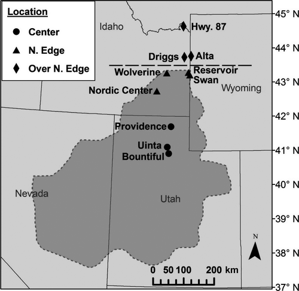

**Figure 1**

### 2.2 Density across the distribution

To determine *A. utahensis* abundance at the centre and northern edge of the distribution, we placed multiple transects through each population in randomly chosen locations and sampled *A. utahensis* density in 1-m<sup>2</sup> quadrats placed every 2 m on alternating sides of transect lines. Near the peak of flowering in late May to early June of 2014 and 2016, we recorded the number of *A. utahensis* within each of three stage classes (seedlings, juveniles, and reproductive adults) in 50 quadrats per population in each study population. Seedlings were defined as newly germinated plants with cotyledons still attached, juveniles were defined as vegetative plants lacking cotyledons or developing racemes, and reproductive adults were plants with either developing racemes or flowers at the time of the census. We recorded the density of different stage classes to evaluate whether variation in density across the centre–north portion of the range was more strongly driven by declines in some life stages than others.

### 2.3 Demographic monitoring

In April and May 2013, we marked individuals within three populations near the centre of the geographic distribution of *A. utahensis* and in three populations at the northern edge of its distribution with numbered metal tags (Figure 1). In April 2014, we marked individuals in an additional population at the northern edge (Swan; Figure 1). In each population, we haphazardly marked 60–80 seedlings, 40–60 juveniles, and 30–35 reproductive adults. The number of plants included in each class was chosen to account for higher predicted mortality in younger classes and to standardize monitoring efforts among populations. While ideal protocol is to mark plants within randomly placed quadrats or along a randomly placed transect, the relatively low-density and patchy distribution of plants in the study populations made this approach unfeasible. Instead, we made an effort to mark plants such that they were spread throughout the population in a manner reflective of their somewhat patchy local distribution. We performed a search for individuals of each life stage throughout the entire population at the beginning of the growing season and attempted to mark 60–80 seedlings, 40–60 juveniles, and 30–35 reproductive adults evenly throughout the area of the population in order to account for microsite variation. Due to a paucity of plants, only 25 reproductive individuals were marked in the northern Swan population. We maintained the number of marked plants within each life stage throughout the duration of the study, tagging 60–80 new seedlings in April of 2014 and 2015, replacing any plants that had died with newly marked plants of the same life stage class, and replacing any juveniles that had become reproductive with new juvenile plants. Across all populations, the transition from the juvenile to the reproductive stage took on average 1.25 growing seasons to complete, meaning that the majority of juveniles became reproductive in the following growing season. We followed the fates of, and recorded vital rates for, all marked individuals from 2013 to 2016.

Beginning in April–May of 2013 and each April thereafter through 2016, we recorded the size of all marked juvenile and reproductive plants. We did not measure the size of seedlings as they were similarly sized across all study populations (K. C. Baer, pers. obs.). Plant size was defined as the area of the basal rosette and calculated using measures of the diameter according to the formula for the area of an ellipse. Basal rosette area is strongly correlated with other measures of plant size such as above-ground biomass (Baer & Maron, 2018a). We calculated yearly growth rates by comparing the size of a plant from each year to the subsequent year. Following the cessation of fruiting but preceding fruit dehiscence/abscission in the 2013–2016 growing seasons, we counted the number of fruits produced by each marked reproductive plant in each study population. When plants produced >10 fruits, we randomly collected 10 fruits per plant; all fruits were collected on plants that produced ≤10 fruits. We determined mean seed production per fruit and multiplied total fruit production for a plant by its mean seed production per fruit to estimate per capita seed production for each growing season. We also monitored the survival of all marked individuals over each yearly transition. We determined the size of seedlings which had survived the yearly transition during the first survey of each growing season and recategorized them as juveniles.

### 2.4 Population projection modelling

We estimated the stochastic population growth rate (hereafter, *λ*<sub>s</sub>) for each of the study populations by constructing separate size-structured integral projection models for each population over the 2013–2014, 2014–2015, and 2015–2016 transitions using demographic data collected over each transition (IPM; Easterling, Ellner, & Dixon, 2000; Ellner & Rees, 2006; IPMpack; Metcalf, McMahon, Salguero-Gómez, & Jongejans, 2013). For the Swan population, we constructed models for the 2014–2015 and 2015–2016 transitions only as demographic data was not collected from 2013 to 2014 in this population. Standard IPMs estimate vital rates as functions of a continuous trait (often size) rather than according to membership in an often arbitrarily defined stage or age class, although IPMs can also incorporate discrete stages (Easterling et al., 2000; Merow et al., 2014). Our IPMs contained a continuous stage describing size-based vital rates of juvenile and reproductive adult plants and two discrete stages in which constants described the vital rates of seedlings (whose size was not recorded) and seeds within the seed bank. The continuous stage of our IPMs was structured according to log-transformed basal rosette area (hereafter, size) and integrated across a range of sizes from the minimum size to 1.2 times the maximum size of any individual recorded in a population throughout all years of the study. We defined the maximum size in this manner to prevent eviction of individuals of the largest size classes from models (Williams, Miller, & Ellner, 2012).

Within the continuous portion of the IPMs, logistic regressions with a logit link described size-based binomial survival probability. Linear models described size-based growth rates and variance around this relationship. Log-transformation of plant size eliminated the need for a size-based estimate of the variance around the size–growth relationship for most models, as verified by a Breusch–Pagan test performed on each model for this relationship (bptest, lmtest package, Zeileis & Hothorn, 2002). In these cases, variance was described according to the residual standard deviation. For size-growth models that remained heteroscedastic following log-transformation of plant size, we described variance in growth as an exponential function of log-transformed plant size when constructing growth models: *σ*(size) *=* sqrt(*σ*<sup>2[2*constant*size]</sup>), where the constant and *σ*<sup>2</sup>were calculated within IPMpack (makeGrowthObj, IPMpack, Metcalf et al., 2013). Models for size-based fecundity comprised logistic regressions with a logit link to describe the size-based probability of flowering and quasi-Poisson regressions with a log link and an overdispersion parameter to describe size-based per capita seed production. We prevented unrealistically high estimates of per capita seed production by the largest individuals in the model by capping seed production in each model at the maximum observed seed production for that population and transition. The maximum seed production varied widely among years in some study populations; incorporating transition-specific values for this model constant allowed us to more accurately capture this variation in models for data from a specific transition year (Supporting Information Appendix S1). We compared the fit of models containing linear and quadratic terms for each vital rate using their corrected Aikake Index Criterion scores (AIC*<sub>c</sub>*; quasi-AIC*<sub>c</sub>*—QAIC*<sub>c</sub>*—for models of overdispersed per capita seed production). If Δ(Q)AIC*<sub>c</sub>* was >2, we selected the model with the lower score unless the model was graphically determined to be biologically unrealistic (Supporting Information Appendix S1). In cases where Δ(Q)AIC*<sub>c</sub>* was ≤2, we constructed models with averaged parameters weighted by (Q)AIC*<sub>c</sub>* score (model.avg; MuMIn package; Barton, 2016).

The discrete seedling stage of each model comprised constants calculated from rates of seedling survival and the size of surviving seedlings for each transition. The results of a seed addition experiment (Baer & Maron, 2018a, 2018b) informed the constants that described estimated recruitment from seeds produced in the previous season and from the seed bank; these remained identical for each transition year within a population. We calculated these constants by sowing seeds sourced from within the same study population in replicate blocks located throughout each study population. In each population, the number of recruits was monitored throughout the subsequent season. The total number of recruits was then divided by the total number of added seeds to estimate recruitment from seeds produced the previous growing season. Germination from the seed bank was estimated as the total number of recruits in each block in the third year after sowing (the second year in the Swan population, which was added to the study in its second year) divided by number of seeds estimated to remain in the block (after accounting for past recruits) and was averaged across all blocks within a population. All seeds that did not germinate were assumed to enter the seed bank; seed bank entry was described according to a constant calculated by comparing sowing density and germination rates in seed addition plots. As we did not directly measure the rate at which seeds remained viable in the seed bank, we assigned this vital rate a value reported for another species of *Astragalus* with a similar life history (Martin, 2010). Additional details of IPMs construction, models, and parameters are presented in Supporting Information Appendix S1.

We discretized the continuous portion of each model into a 100*100 cell matrix and added the discrete stages to the discretized matrix to form the IPM. Using this matrix, we calculated projected *λ* (the dominant eigenvalue) for each model. We then determined the vital rates that contributed the most to the estimate of *λ* from each IPM by calculating the elasticity of each constant describing the discrete stages and each parameter in the vital rate models that composed the continuous portion of the IPM (sensParams, IPMpack, Metcalf et al., 2013; Supporting Information Appendix S2). Elasticity describes the standardized impact of each vital rate on the value of *λ*, which allows for comparison of their relative contributions to the estimated value of *λ* in a population (de Kroon, Plaiser, van Groenendael, & Caswell, 1986). We also used a life table response experiment (LTRE) to compare models for each central population to models for each northern population to evaluate the vital rates that were primarily responsible for differences in *λ*<sub>s</sub> among populations at the two range positions (Supporting Information Appendix S2).

We used IPMs for the 2013–2014, 2014–2015, and 2015–2016 transitions (2014–2015 and 2015–2016 in the Swan population) to estimate *λ*<sub>s</sub> for each study population. To do this, we applied a randomly chosen IPMs from among the three IPMs for each population (two IPMs for the Swan population) to a population vector 4,000 times (discarding the first 2000 runs to prevent bias from initial conditions) and determined the value upon which population growth rate converged (stochGrowthRateSampleList, IPMpack, Metcalf et al., 2013; Metcalf et al., 2015).

To estimate a confidence interval for *λ* in each population, we constructed 500 IPMs for each transition in each population using bootstrapped datasets of the same size as the original dataset created via random selection of individuals with replacement (in keeping with methods outlined in Kalisz & McPeek, 1992). We used this method because the width of a confidence interval obtained using repeated iterations of the function used to calculate *λ*<sub>s</sub> is highly dependent upon the number of iterations used and may underestimate the variation around stochastic lambda with only three transitions included in the equation. The approach of building “bootstrapped” IPMs allowed us to estimate a confidence interval for *λ* in each population that was less likely to over- or underestimate the width of this interval. Component models for survival, growth, and reproduction in these bootstrapped IPMs contained the same terms as those for the original dataset and parameters derived from the bootstrapped dataset. We calculated *λ* for each of the bootstrapped IPMs, resulting in 1,500 estimates of *λ* for each population over the three transitions (1,000 in the Swan population over two transitions). We estimated the 95% confidence interval for *λ* as the interval between the 2.5th and 97.5th percentiles of the distribution of the 1,500 (1,000 in the Swan population) values of *λ* (Tenhumberg Suwz, Tyre, Russell, & Louda, 2015).

### 2.5 Transplant populations over the northern distributional edge

We established three transplant sites beyond the northern range edge to test for dispersal limitation (Figure 1). These sites were chosen by first examining aerial imagery for habitat with characteristics similar to those observed in populations of *A. utahensis* within the range, including sparse vegetative cover and visible bare ground, southern aspect, and relatively steep slopes. We visited each of the nine resulting candidate sites and evaluated conditions on the ground. We then chose the three sites most likely to be suitable based upon their similarity to habitat characteristics of northern range edge populations and their relatively high suitability scores calculated using a climate niche model for *A. utahensis* (Baer, 2017). Two transplant sites were located within 50 km of the furthest north recorded *A. utahensis* population (Driggs and Alta; Figure 1), and the third was roughly 150 km north of the furthest north population within the range (Hwy. 87; Figure 1). We transplanted seedlings into these populations in 2014 and both seedlings and juveniles in 2015. Transplanting juveniles at and beyond the range edge also allowed us to compare the ability of plants to reproduce in both locations and to disentangle the relative effects of transplanting vs. geographic position on plant growth and reproduction. As a general rule, climatic conditions during the transplant experiment were not anomalous and fell within the 95% confidence interval for 30-year averages in each site, although temperatures were generally somewhat warmer and precipitation generally higher than the 30 year average during the period in which the study was conducted (NOAA, 2018; Supporting Information Appendix S3).

Transplants were started in a greenhouse at the University of Montana. In the first year of the transplant experiment (2014), seeds used to grow seedlings were sourced from a single northern population due to a paucity of available seeds from other northern populations. In 2015, all seedling and juvenile transplants were grown from seeds sourced from the four northern populations included in this study. Juveniles were grown in the greenhouse for roughly 6 months and seedlings for roughly 1 month before transplanting.

In April–May 2014, we transplanted 100 seedlings into each of the three sites located over the northern range edge (Driggs, Alta, and Hwy. 87; Figure 1) and into the two northernmost edge populations (Wolverine and Reservoir; Figure 1). Seedlings were transplanted in four blocks of 25 seedlings. Within each 40-cm<sup>2</sup> block, seedlings were randomly placed in five rows and five columns spaced 10 cm apart to avoid competition with neighbouring transplanted seedlings. We placed blocks in areas of the site that possessed characteristics known to be associated with patches of *A. utahensis* in northern edge populations, including sparse vegetation, southern aspect, and relatively steep slopes. Survival of transplanted seedlings from 2014 to 2015 was higher than we initially anticipated; we therefore determined that fewer transplants were necessary to accurately describe transplant demography in the second year of the experiment. In May 2015, we added 50 seedlings and 30 juvenile plants to each of the three over-the-edge transplant populations and the two northernmost populations in 5 blocks of 10 seedlings and 5 blocks of 6 juveniles each. Blocks of transplanted seedlings contained two rows of five columns, with all seedlings spaced 10 cm apart. Blocks of transplanted juveniles were arranged in two rows of three columns, with juveniles spaced 10 cm apart. The placement of blocks was determined as described above, and the placement of plants within each block was random. As with demographic surveys performed on naturally occurring plants, the size of seedlings was not determined at transplanting. We measured the basal rosette area of juveniles as described above at the time of transplanting.

In May 2015 and 2016, we evaluated the survival of transplants. We marked all surviving seedlings with a uniquely numbered metal tag and all surviving plants were measured to determine basal rosette area. If a plant had been a juvenile with a measure of basal rosette area from the previous census, we determined basal rosette growth over the yearly time step. In late June 2016, we surveyed the sites for total fruit production by any reproductive transplants. If a plant produced ≤10 fruits, we collected all fruits from the plant; we collected a maximum of 10 fruits from plants that produced >10 fruits. We counted the mean number of seeds per fruit and estimated total seed production per plant as described above.

We performed seed additions at each of the transplant sites over the northern range edge to evaluate germination rates and compare them to germination rates within the current range as reported in a previous study (Baer & Maron, 2018a, 2018b). In June–July 2014, we collected seeds from the four northern study populations for use in the seed addition experiment. In August 2014, we added seeds to five replicate blocks containing four 0.5 m × 0.5 m plots each, randomly assigning plots within a block to a sowing density of 25, 50, 100, or 200 seeds per 0.25 m<sup>2</sup>to five replicate plots per site in August 2014. The sowing densities represented a biologically realistic range of seed rain and matched that of seed additions performed within the range as reported in Baer and Maron (2018a, 2018b ). Blocks were placed >1 m from any transplanted individuals to prevent dispersal of additional seeds from reproductive transplants into seed addition plots and were arranged haphazardly throughout the plot, with distances between blocks ranging from 5 to >100 m. We monitored seed addition plots for emergence in May 2015 and 2016 and estimated total germination from the seed bank after 2 years in 2016. Following the fate of seedlings that germinated naturally in these plots in 2015 and comparing their vital rates to those transplanted in 2015 would have been ideal for informing our understanding of seedling performance beyond the northern range edge. However, too few seedlings germinated in the seed addition plots in the year following seed addition for this comparison to be made: study sites over the northern edge had an average of one germinant per site and populations at the northern edge had an average of five germinants per site in 2015.

### 2.6 Statistical analyses

Statistical analyses were conducted using r Statistical Software (version 3.4.0; R Core Development Team, 2017). In all analyses, we used population as the unit of replication. We evaluated measures of density and population growth using linear regressions across the latitudinal position of study populations to evaluate the ACH prediction that monotonically decreasing environmental suitability from the range centre to its edge should prompt a similar linear decline in density and population growth from the centre to the edge of the range (Brown, 1984; Sagarin & Gaines, 2002). Although for the sake of simplicity populations were roughly defined into “central” and “northern edge” categories during sampling, sufficient latitudinal spread existed among populations to render linear regression appropriate. To ensure that the results of linear regressions were in keeping with comparisons of central and northern populations as groups, we also performed ANOVA to test for differences in mean density and population growth among populations at the centre and the northern edge (Supporting Information Appendix S4). To determine how plant density varied across the latitudinal range of study populations, we compared the summed density of all life stages among central and northern edge populations using repeated-measures linear mixed model with the latitude of study populations, census year (2014 or 2016), and their interaction as explanatory variables (lmer, lme4 package, Bates, Maechler, Bolker, & Walker, 2015; lmerTest, lmerTest package, Kuznetsova, Brockhoff, & Christensen, 2016; ANOVA, r base package). Site was included as a random effect to account for multiple measures of density across years in each site. Using a simple linear regression, we evaluated whether *λ*<sub>s</sub> changed in a predictable manner across latitude in populations from the centre of the distribution to its northern edge (lm and ANOVA; r base package). We also used simple linear regression to evaluate the relationship between the mean value for observed density of all life stages combined across both censuses in each population and projected *λ*<sub>s</sub>, as well as performing this comparison for both censuses independently.

We used repeated-measures ANOVA to compare the mean survival of transplanted seedlings 1 year after they were transplanted at the northern range edge and beyond the northern range edge (i.e., survival of 2014 transplants to 2015 and 2015 transplants to 2016). The fixed effects in these models included geographic location (at vs. beyond the northern edge), year, and their interaction; site was included as a random effect. A similar model was used to compare the mean log-transformed sizes of surviving seedlings among geographic locations and transition years. We used one-way ANOVAs to compare the mean survival rates and mean basal rosette growth of juvenile transplants from 2015 to 2016 among the two northernmost populations and the three sites beyond the northern edge. Juvenile plants transplanted into northern populations first became reproductive in 2016; we compared mean per capita seed production by transplants that flowered (i.e., reproductive transplants) among geographic locations in this year using a one-way ANOVA. We also compared mean cumulative seedling emergence over 2 years at each of the four sowing densities among northern edge sites and sites beyond the northern edge using a two-way ANOVA that included sowing density, geographic position, and their interaction as explanatory variables.

## 3 RESULTS

### 3.1 Density and population performance across the distribution

The summed density of all life stages of *A. utahensis* declined significantly from the centre of the distribution to its northern edge across both censuses, although the slope of this decline was significantly more negative in the 2016 census than the 2014 census (Figure 2a; latitude: *F*<sub>1,5</sub> = 10.2; *p* < 0.05; year: *F*<sub>1,5</sub> = 8.5; *p* < 0.05; latitude*year: *F*<sub>1,5</sub> = 8.1; *p* < 0.05). The high density recorded in the Bountiful population in 2016 did not solely drive this relationship; the correlation remained significantly negative even when this data point was excluded from the analysis (*Adj. R*<sup>2</sup> = 0.61; *F*<sub>1,4</sub> = 8.9; *p* < 0.05). This relationship was also significant for all individual life stages (seedling, juvenile, and reproductive plants) in both census years except juvenile plants in 2014 and seedlings in 2016, which showed a marginally significant negative relationship with increasing latitude in these years (K. C. Baer & J. L. Maron; unpubl. data).

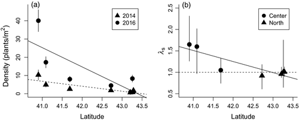

**Figure 2**

(a) Mean (±*SEM*) plant density vs. latitude of study populations from the range centre to the northern edge. Triangles and dashed line represent values from the 2014 census; circles and solid line represent the 2016 census. (b) Projected *λ*<sub>s</sub> and bootstrapped 95% confidence intervals for *λ* vs. latitude for central and northern edge study populations. The dashed line represents *λ* = 1; the replacement rate

Projected stochastic population growth rate (*λ*<sub>s</sub>) declined significantly from the centre of the distribution to the northern range edge (Figure 2b; *Adj. R*<sup>2</sup>= 0.71; *F*<sub>1,5</sub> = 15.7; *p* < 0.05). The 95% confidence intervals for *λ* for all populations except the southernmost site (Bountiful) overlapped the replacement rate (*λ* = 1; Supporting Information Appendix S1). The mean density of all life stages combined across both censuses was significantly positively correlated with estimates of *λ*<sub>s</sub>for each population (*Adj. R*<sup>2</sup> = 0.74; *F*<sub>1,5</sub> = 18.2; *p* < 0.01), indicating that we could detect no density dependence in rates of population growth within the study populations.

### 3.2 Demographic drivers of population growth rate

In most IPMs, per capita seed production was the life stage with the highest elasticity (Supporting Information Appendix S2). Plant growth rate also had relatively high elasticity in most models. LTREs comparing each central population and each northern population revealed three primary contributors to the decline in population growth rate from the centre of the distribution to the northern edge. These were a decrease in the size of surviving seedlings, total seed production at the population scale, and rates of recruitment from the seed bank (Supporting Information Appendix S2). Declines in other demographic rates also contributed to the decrease in *λ*<sub>s</sub> from the centre to the edge of the distribution, albeit to a much lesser extent.

### 3.3 Performance beyond the northern range edge

Seedling survival over the first year after transplanting did not differ among geographic locations (northern edge vs. beyond the edge), regardless of the year in which seedlings were transplanted (Figure 3a; geographic position: *F*<sub>1,6</sub> = 0.4; *p* = 0.58; year: *F*<sub>1,6</sub> = 2.3; *p* = 0.18; geographic position*year: *F*<sub>1,6</sub> = 3.5; *p* = 0.11); nor did the mean log-transformed size of surviving transplanted seedlings differ among locations (northern edge: 1.94 ± 0.35; over northern edge: 1.30 ± 0.25; geographic position: *F*<sub>1,6</sub> = 2.3; *p* = 0.18; year: *F*<sub>1,6</sub> = 0.9; *p* = 0.39; geographic position*year: *F*<sub>1,6</sub> = 0.8; *p* = 0.41). Transplanted juvenile plants also did not differ among geographic locations in their rates of survival from 2015 to 2016 (Figure 3b; *F*<sub>1,3</sub> = 0.1; *p* = 0.78). The mean growth of transplanted juvenile plants from 2015 to 2016 was significantly greater in northern edge populations, where on average plants grew from one year to the next, as compared to transplant sites beyond the edge, where on average plants tended to shrink across years (Figure 3c; *F*<sub>1,3</sub> = 103.7; *p* < 0.01).

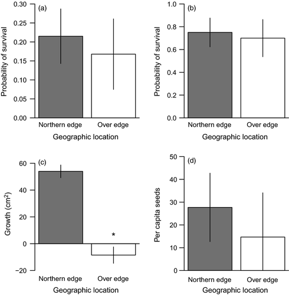

**Figure 3**

Comparisons of the demography of transplanted individuals at the northern edge of the distribution and beyond the northern edge. Mean (±*SEM*) (a) survival probability of transplanted seedlings after 1 transition (survival of 2014 transplants to 2015 and 2015 transplants to 2016), (b) survival probability of transplanted juvenile plants from 2015 to 2016 (c) basal rosette growth of transplanted juveniles from 2015 to 2016, and (d) per capita seed production in 2016. Significant differences are indicated with an asterisk

In 2016, 48.4% of transplants that were categorized as juveniles at the end of the 2015 growing season and survived to 2016 became reproductive in the Wolverine study population (*n =* 15/31) and 38.6% did so in the Reservoir population (*n =* 17/44). Beyond the northern range edge, 53.8% became reproductive in the Alta site (*n =* 21/39), 16.1% in the Driggs site (*n =* 5/31), and 26% in the Highway 87 site (*n =* 13/50). Mean per capita seed production was not significantly different among transplants at the northern edge and beyond the northern edge in 2016 (Figure 3d; *F*<sub>1,3</sub> = 0.4; *p* = 0.55). Cumulative emergence in seed addition plots after 2 years increased significantly with sowing density in both northern populations and over-the-edge sites but was not significantly different between geographic locations (sowing density: *F*<sub>1,24</sub> = 16.9; *p* < 0.001; geographic position: *F*<sub>1,24</sub> = 0.9; *p* = 0.36; sowing density*geographic position: *F*<sub>1,24</sub> = 0.3; *p* = 0.60).

## 4 DISCUSSION

In this study, we tested two key predictions of metapopulation models for the determinants of range limits by simultaneously examining variation in demographic performance across a species’ distribution, integrating demographic rates to quantify variation in population growth across the range, and estimating the suitability of habitat for plant persistence at and beyond the northern range edge (thus testing for dispersal limitation). Projected population growth declined from the centre of the distribution to its northern edge as predicted by niche-based explanations for range limits stemming from the ACH (Brown, 1984; Hengeveld & Haeck, 1982; Pironon et al., 2017; Sagarin et al., 2006). Nonetheless, the results of our transplant experiment suggest that suitable habitat exists for *A. utahensis* beyond the northern range edge. These findings imply that limits to the northern distribution are imposed both by niche constraints and dispersal limitation, in keeping with the predictions of metapopulation models. This result was only revealed by examining multiple aspects of demographic performance from the interior of the distribution to its northern range edge and beyond the northern range edge, an approach that is seldom taken in studies of latitudinal range limits.

Niche-based explanations for range limits derived from the ACH posit that the density and performance of populations should decrease monotonically from the centre of the distribution to the edge due to declining habitat suitability, leading to an inability to maintain viable populations beyond the range edge (Brown, 1984; Holt, 2003; Pironon et al., 2017; Sagarin et al., 2006). In contrast, metapopulation models predict a decline in landscape-scale performance, but do not necessarily predict that all central populations are well-performing, nor that all edge populations are poorly performing (Carter & Prince, 1981; 1988; Gaston, 2009; Holt & Keitt, 2000; Holt et al., 2005). We observed a significant decline in both plant density and projected *λ*<sub>s</sub>with increasing latitude as predicted by ACH-derived niche-based hypotheses, but the pattern we observed did not suggest categorically high performance in all populations at the centre of the range. Rather, the northernmost central population (Providence) showed relatively low density and predicted *λ*<sub>s</sub> compared to other central populations (Figure 2; Supporting Information Appendix S1). This suggests that niche processes contribute to constraining performance across the distribution, although habitat suitability and resultant abundance and population performance are not a monotonic function of distance from the range centre. In this regard, our findings are consistent with the predictions of metapopulation models. This conclusion is supported by the fact that central populations as a group are marginally denser and have significantly higher population growth rates than northern populations as a group, despite the relatively low abundance and poor performance of one central population (Supporting Information Appendix S4).

In accordance with other studies that have observed declines in *λ* towards the boundary of a species’ latitudinal or longitudinal distribution (Eckhart et al., 2011; Stanton-Geddes et al., 2012), changes in biotic and abiotic conditions appear to impose increasingly harsh limits on *A. utahensis* population performance with proximity to the edge. In a companion study, we found that both pre-dispersal seed predation by insects and pollen limitation substantially reduce *A. utahensis* seed production and population growth (Baer & Maron, 2018a, 2018b). Although these biotic factors reduced *A. utahensis* population growth by similar amounts at the range centre and northern range edge, in the north they reduce lambda to close to the replacement level. Thus, biotic checks on reproduction and population growth clearly contribute to setting the northern range boundary. Changing climatic conditions from the centre of the distribution to the northern edge also appear to spur the observed decline in *λ*<sub>s</sub>across this portion of the range. A significant positive relationship exists between model-derived estimates of climatic suitability and *λ*<sub>s</sub> in study populations across the centre-north portion of the distribution (Baer, 2017). These estimates were determined primarily by precipitation in the wettest quarter of the year (higher in central than northern populations), and to a lesser extent by mean temperature in the warmest and driest quarters of the year and isothermality (higher in central than northern populations), along with temperature in the wettest quarter of the year (higher in northern than central populations; Baer, 2017), indicating that these aspects of the abiotic environment are correlated with population performance.

Most empirical tests of performance across the distribution of species examine only one or a few aspects of demography (Gaston, 2009; Sexton et al, 2009), assuming that the magnitude of change in these metrics for individuals directly translates to the magnitude of their effect upon population performance. Contrary to this assumption, we found that some aspects of individual demographic performance that decline strongly from the centre of the distribution to its edge (e.g., survival) contribute less to declining population growth than others that do not decline significantly over this portion of the range (e.g., basal rosette growth rate and per capita seed production; Baer, 2017). In addition, we found that variation in two rarely examined vital rates, the size range of surviving seedlings and emergence from the seed bank, contributes strongly to the pattern of declining population growth across this portion of the latitudinal range. Our study supports previous contentions that examining one or a few vital rates when evaluating potential drivers of population growth across the range is likely to result in inaccurate or biased conclusions (Gaston, 2009; Villellas et al., 2015).

Two important caveats should be mentioned regarding the interpretation of our transplant experiment results. First, we only followed the fate of over-the-edge transplants for a limited time span. As a result, we could not capture the influence of rare events that may periodically drive populations beyond the current boundary to local extinction (Carter & Prince, 1981; 1988; Gaston, 2009; Holt & Keitt, 2000; Holt et al., 2005). However, if our results are representative of the dynamics of *A. utahensis* beyond the current range, they point towards a role for dispersal limitation in maintaining the northern range limit. Second, while most vital rates beyond the range edge did not differ significantly from those of transplants at the northern edge of the distribution, this does not necessarily indicate a lack of biologically relevant differences. The fact that *λ*<sub>s</sub> in northern edge sites was very close to the rate of replacement also means that a decrease in any vital rate, even those that contribute relatively little to population growth, may render populations beyond the range edge incapable of long-term viability (Carter & Prince, 1988). Unlike all other vital rates we examined, growth rates of transplanted juveniles were significantly lower in sites beyond the northern range edge. Plant growth was the strongest contributor to *λ* in IPMs for some transitions in one of the northern edge sites acting as a control (Reservoir; Supporting Information Appendix S2), which may mean that lower growth rates of transplants beyond the range edge results in population growth below replacement at these sites.

While these possibilities preclude us from unequivocally stating that dispersal limitation constrains *A. utahensis*’ northern range, we believe that sufficient evidence exists to support our conclusion. A climatic niche model for *A. utahensis* projects large but patchy areas of highly suitable but unoccupied habitat beyond the northern boundary of the range (Baer, 2017). Model-estimated environmental suitability has been found to be strongly correlated with estimates of *λ*<sub>s</sub> in *A. utahensis* (Baer, 2017). Projected environmental suitability is more strongly correlated with demographic performance than geographic position in several other species, as well (Pironon et al., 2017). Moreover, the performance of transplants beyond the northern range edge varied substantially among transplant sites, indicating that while some sites are undoubtedly unsuitable, others may be capable of supporting viable populations (Supporting Information Appendix S5). While transplants in all beyond-the-edge sites grew less on average than those within northern edge populations, some amount of demographic compensation (Villellas et al., 2015) may offset the impact of this declining growth on the performance of transplant “populations.” Survival, reproduction, or germination rates of transplants in individual beyond-the-edge sites often exceeded those observed for transplants in control sites at the northern range edge (Supporting Information Appendix S5), and individuals in the beyond-the-edge Alta site became reproductive at a higher rate than transplants in either control site at the northern range edge. Therefore, while average performance may have been lower beyond the northern range edge, areas suitable for the maintenance of viable populations presumably still exist beyond the northern range boundary.

Dispersal limitation may commonly contribute to the establishment of range limits, particularly at latitudinal boundaries. A meta-analysis of transplant experiments at and beyond geographic range edges found that five of six studies in which at least two vital rates were monitored demonstrated the species’ ability to survive, grow, or reproduce at rates similar to that of individuals within the range (Hargreaves et al., 2014), although decreases in performance towards the distributional edge are not uncommon (Pironon et al., 2017; Sexton et al., 2009; e.g., Battisti et al., 2005; Geber & Eckhart, 2005; Latimer, Silander, Rebelo, & Midgley, 2009; Levin & Clay, 1984; Samis & Eckert, 2009). *Astragalus utahensis* displays an analogous pattern of decreasing performance towards the range edge coupled with similar performance at and beyond the edge. Species such as *A. utahensis,* which produce fairly large seeds and lack highly mobile animal dispersal vectors, are likely to disperse only short distances from the parent plant (Hewitt & Kellman, 2002). The current distributional boundary of *A. utahensis* may result from a lag in colonization following glacial retreat, a condition thought to be common in European and North American species (Normand et al., 2011; Qian & Ricklefs, 2007; Svenning, Normand, & Skov, 2008). It is also possible that increasing temperature and precipitation related to recent climate change have led to the development of suitable habitat beyond the current northern boundary of *A. utahensis’* distribution, which may result in a future range shift in response to changing climatic conditions (Parmesan, 2006; Parmesan & Yohe, 2003; Walther et al., 2002). The transplant sites included in this study were 50–150 km north of the current northern range boundary. Given the local dispersal of *A. utahensis* seeds, these sites and other suitable habitat beyond the northern range limit may remain uncolonized for a long period of time.

## 5 CONCLUSIONS

This study is one of the first to simultaneously examine multiple aspects of demographic performance both across and beyond the distribution of a species and to demonstrate that both niche and dispersal mechanisms appear to limit the latitudinal extent of a species’ range. The only other studies of which we are aware that have coupled examinations of population performance from the interior to the edge of a species’ range with transplant experiments beyond the edge found either strong evidence for range limits determined solely by declining demographic performance (indicating a niche limit; Stanton-Geddes et al., 2012) or dispersal limitation of the distribution without an accompanying decline in demographic performance (Samis & Eckert, 2009). In contrast, our findings are consistent with the predictions of metapopulation models that species range limits often result from both niche and dispersal constraints (Carter & Prince, 1981; 1988; Gaston, 2009; Holt & Keitt, 2000; Holt et al., 2005; e.g., Angert et al., 2018).

The results of our study add to a growing body of evidence in support of metapopulation models for range limits. In keeping with the predictions of metapopulation models, species occupancy has been shown to decline with proximity to the range edge in 17 of 21 past tests (81%; Pironon et al., 2017). Additionally, a review of past transplant experiments beyond latitudinal and longitudinal range limits suggests that dispersal limitation of these ranges is more common than previously thought (Hargreaves et al., 2014). Angert et al. (2018) observed both patterns in *Erythranthe cardinalis,* in which both the occupancy of model-predicted suitable habitat patches declined towards the northern range edge and unoccupied suitable habitat was predicted to exist beyond this edge, suggesting a poleward distribution simultaneously limited by declining fitness and dispersal such as that observed here. Future studies that manipulate aspects of the environment and examine demographic responses at and beyond range edges will allow us to further evaluate the extent to which metapopulation models accurately describe the mechanisms underlying stable range limits and to more accurately identify the specific environmental conditions contributing to observed patterns (Ehrlén, Morris, von Euler, & Dahlgren, 2016).

## ACKNOWLEDGEMENTS

The authors thank Peggy Stolworthy, Cynthia Salisbury, and the U.S. Forest Service for permission to perform work on public and private lands in Utah and Idaho. We also thank Zachary Baer, Christina Cain, Becky Fletcher, Allison Klocke, Mike Kimball, Eric Mohrmann, and Jennifer Neville for their assistance with field work. Assistance with integral projection model construction was provided by Emilio Bruna, Johan Ehrlén, Phillip Hahn, Loralee Larios, Roberto Salguero-Gómez, and the Max Planck Institute for Demographic Research. This material is based upon work supported by the National Science Foundation Graduate Research Fellowship under NSF Grant No. DGE-1313190 and an Oak Ridge Institute for Science and Education post-doctoral fellowship. J.L.M. was supported by NSF grants DEB-0614406 and DEB-1553518. The authors have no conflicts of interest to declare.

## AUTHORS' CONTRIBUTIONS

K.C.B. and J.L.M. developed the question and methodologies described in this paper; K.C.B. collected and analysed the data and led the writing of the manuscript; J.L.M. contributed critically to data analysis and drafts of the manuscript. Both authors gave final approval for publication.

## DATA ACCESSIBILITY

Data associated with this study are archived in the Dryad Digital Repository: https://doi.org/10.5061/dryad.894jc22 (Baer & Maron, 2018b).

## Citing Literature

[figure not shown]

May 2019

Pages 1250-1262

This article also appears in:

[figure not shown]